# Plotly & Seaborn

In this practice, you will learn to create statistical charts using data visualization libraries Plotly and Seaborn.

1. You will create 10 charts.
2. Load HollywoodsMostProfitableStories.csv and use Plotly to create the following charts. Every figure must include a title. Each axis must be labeled.

```python
import warnings
warnings.filterwarnings("ignore")
```

```python
import pandas as pd
film=pd.read_csv("HollywoodsMostProfitableStories.csv")
film.head()
```

|  | Film | Genre | Lead Studio | Audience score % | Profitability | Rotten Tomatoes % | Worldwide Gross | Year |
| --- | --- | --- | --- | --- | --- | --- | --- | --- |
| 0 | 27 Dresses | Comedy | Fox | 71.0 | 5.343622 | 40.0 | 160.308654 | 2008 |
| 1 | (500) Days of Summer | Comedy | Fox | 81.0 | 8.096000 | 87.0 | 60.720000 | 2009 |
| 2 | A Dangerous Method | Drama | Independent | 89.0 | 0.448645 | 79.0 | 8.972895 | 2011 |
| 3 | A Serious Man | Drama | Universal | 64.0 | 4.382857 | 89.0 | 30.680000 | 2009 |
| 4 | Across the Universe | Romance | Independent | 84.0 | 0.652603 | 54.0 | 29.367143 | 2007 |

a. A bar chart showing the profitability of the film. The X-axis is the film. The Y-axis is profitability. The bars should be sorted from the most to the least profitable.

```python
import plotly.express as px
```

```python
film_sort=film.sort_values('Profitability', ascending=False)
fig_2a=px.bar(film_sort, x='Film', y='Profitability', title='2.a Profitbality of film')
fig_2a.show()
# fig_2a.write_image('fig_2a.png')
```

[interactive chart not shown]

b. A histogram showing the number of films for each Genre. The X-axis is the Genre. The Y-axis is the number of films in the spreadsheet from each Genre.

```python
fig_2b=px.histogram(film, x='Genre', histfunc='sum',title='2.b Number of films of each Genre')
fig_2b.show()
# fig_2b.write_image('fig_2b.png')
```

[interactive chart not shown]

c. A figure with two bar plots: Worldwide Gross and Audience. The X-axis is the film index. When the mouse cursor hovers over a bar, the film’s title should be displayed in the tooltip.

```python
from plotly.subplots import make_subplots
import plotly.graph_objects as go
```

```python
fig_2c=make_subplots(rows=2, cols=1, shared_xaxes=True, vertical_spacing=0.05)
fig_2c.add_trace(go.Bar(x=film['Film'].index, y=film['Worldwide Gross'], name='Worldwide Gross',
                       text=film['Film']), row=1, col=1)
fig_2c.add_trace(go.Bar(x=film['Film'].index, y=film['Audience  score %'], name='Audience  score %',
                       text=film['Film']), row=2, col=1)

fig_2c['layout']['xaxis2'].update(title="film name index")
fig_2c['layout']['yaxis1'].update(title="worldwide gross")
fig_2c['layout']['yaxis2'].update(title="audience score%")
fig_2c['layout'].update(title="2.c World wilde gross and Audience score of each film")
fig_2c.show()
# fig_2c.write_image('fig_2c.png')
```

[interactive chart not shown]

d. A line chart showing the profitability of the films over the years. The X-axis is the Year. The Y-axis is the average profitability.

```python
per_year=pd.DataFrame(film.groupby(['Year']).mean())
per_year.head()
```

| Year | Audience score % | Profitability | Rotten Tomatoes % | Worldwide Gross |
| --- | --- | --- | --- | --- |
| 2007 | 66.727273 | 4.058520 | 48.818182 | 119.523219 |
| 2008 | 69.789474 | 8.136442 | 53.789474 | 186.272113 |
| 2009 | 62.750000 | 5.023312 | 44.250000 | 167.282500 |
| 2010 | 55.684211 | 2.227516 | 37.473684 | 89.894684 |
| 2011 | 67.583333 | 3.272555 | 54.583333 | 116.979377 |

```python
fig_2d=px.line(per_year, x=per_year.index, y='Profitability')
fig_2d['layout']['xaxis'].update(title="year", type='category')
fig_2d['layout']['yaxis'].update(title="average profit")
fig_2d['layout'].update(title="2.d Yearly average profitability")
fig_2d.show()
# fig_2d.write_image('fig_2d.png')
```

[interactive chart not shown]

#### plotly express: dot plot

e. A dot plot showing the Rotten Tomato %. The X-axis is the Rotten Tomato %. The Y-axis is the film title.

```python
fig_2e=px.scatter(film, x='Rotten Tomatoes %', y='Film', title='2.e Rotten Tomato % of film')
fig_2e.show()
# fig_2e.write_image('fig_2e.png')
```

[interactive chart not shown]

1. Load Housing_price.csv and use Plotly to create the following charts. Every figure must include a title. Each axis must be labeled.

```python
house=pd.read_csv("Housing_price.csv")
house.head()
#print(house.info())
```

|  | housenum | acre | acregroup | adj1998 | adj2007 | adj2011 | bedgroup | bedrooms | bikescore | diff2014 | ... | price1998 | price2007 | price2011 | price2014 | sfgroup | squarefeet | streetname | streetno | walkscore | zip |
| --- | --- | --- | --- | --- | --- | --- | --- | --- | --- | --- | --- | --- | --- | --- | --- | --- | --- | --- | --- | --- | --- |
| 0 | 1 | 0.28 | > 1/4 acre | 148.3626 | 233.8419 | 191.8211 | 3 beds | 3 | 35 | 62.36645 | ... | 101.5 | 203.5 | 181.1 | 210.729 | <= 1500 sf | 0.966 | Acrebrook Drive | 406 | 9 | 1062 |
| 1 | 2 | 0.29 | > 1/4 acre | 135.2073 | 261.4203 | 206.9677 | 3 beds | 3 | 44 | 68.96375 | ... | 92.5 | 227.5 | 195.4 | 204.171 | <= 1500 sf | 0.960 | Autumn Dr | 57 | 5 | 1062 |
| 2 | 3 | 0.36 | > 1/4 acre | 256.5284 | 401.0359 | 347.9472 | 3 beds | 3 | 66 | 82.13365 | ... | 175.5 | 349.0 | 328.5 | 338.662 | > 1500 sf | 1.725 | Bridge Road | 31 | 46 | 1062 |
| 3 | 4 | 0.26 | > 1/4 acre | 231.6795 | 305.0861 | 257.4915 | 3 beds | 3 | 61 | 44.57055 | ... | 158.5 | 265.5 | 243.1 | 276.250 | > 1500 sf | 1.727 | Bridge Road | 200 | 40 | 1060 |
| 4 | 5 | 0.31 | > 1/4 acre | 271.8762 | 298.7660 | 236.6253 | 4+ beds | 4 | 53 | -102.70300 | ... | 186.0 | 260.0 | 223.4 | 169.173 | > 1500 sf | 1.576 | Bridge Road | 395 | 32 | 1062 |

5 rows × 31 columns

a. A figure that contains three boxplots: price2014, squarefeet, and acre. i. The values in “square feet” and “acre” columns are too small compared with the price column. To make the chart look better, you may multiply “squarefeet” by 1000. (The data in the squarefeet column was divided by 1000.) You may convert the values in the “acre” column to squareyard by multiplying 4840

```python
fig_3a=make_subplots(rows=1, cols=3, shared_yaxes=True,horizontal_spacing=0)
fig_3a.add_trace(go.Box(y=house['price2014'], name='price2014'),row=1, col=1)
fig_3a.add_trace(go.Box(y=house['squarefeet']*1000, name='squarefeet*1000'),row=1, col=2)
fig_3a.add_trace(go.Box(y=house['acre']*4840, name='acre*4080'),row=1, col=3)
fig_3a['layout']['xaxis2'].update(title="Feature")
fig_3a['layout']['yaxis'].update(title="value")
fig_3a['layout'].update(title="3.a Boxplots of price2014, squarefeet and acre")
fig_3a.show()
# fig_3a.write_image('fig_3a.png')
```

[interactive chart not shown]

b. A histogram showing the number of houses per Zip code. The X-axis is the Zip code. Create an annotation pointing to the Zip code with the most houses.

```python
fig_3b=px.histogram(house, x='zip', y='housenum',histfunc='count')
fig_3b.update_layout(title='3.b number of houses per zipcode',
                     xaxis=dict(type='category'),
                     annotations=[ dict( x="1062", y="61", xref='x', yref='y',
                                        text='max houses number 61',
                                        showarrow=True, arrowhead=7, ax=0, ay=-40)])
fig_3b.show()
# fig_3b.write_image('fig_3b.png')
```

[interactive chart not shown]

c. A line chart with four lines: price1998, price2007, price2011, and price2014. The X-axis is the house num. The Y-axis is the value from the four columns listed above. When the mouse cursor hovers over a marker, the street address of the house should be displayed in the tooltip.

```python
house['Address']=house['streetno'].map(str)+''+house['streetname'].map(str)
house_c=pd.melt(house, id_vars=['housenum','Address'],
                value_vars=['price1998','price2007','price2011','price2014'])
fig_3c=px.line(house_c, x=house_c['housenum'], y=house_c['value'],color='variable',
               hover_name='Address',
               title='3.c house price v.s. house number')
fig_3c.show()
# fig_3c.write_image('fig_3c.png')
```

[interactive chart not shown]

1. Load wimbledons_champions.csv and use Seaborn to create the following charts.

```python
import seaborn as sns
import matplotlib.pyplot as plt
```

```python
champ=pd.read_csv('wimbledons_champions.csv')
champ.head()
# print(champ.info())
```

|  | Gender | Champion | Mins | Runner-up Nationality | Champion Nationality | Runner-up | Score | Runner-up Seed | Champion Seed | Year | Runner-up Nationality (Men's) | Runner-Up |
| --- | --- | --- | --- | --- | --- | --- | --- | --- | --- | --- | --- | --- |
| 0 | Men's | G.L. Patterson | NaN | AUS | AUS | N.E. Brookes | 6-3, 7-5, 6-2 | NaN | NaN | 1919 | NaN | NaN |
| 1 | Men's | G.L. Patterson | NaN | GBR | AUS | R. Lycett | 6-3, 6-4, 6-2 | NaN | NaN | 1922 | NaN | NaN |
| 2 | Men's | N.E. Brookes | NaN | GBR | AUS | A.W. Gore | 6-4, 6-2, 6-2 | NaN | NaN | 1907 | NaN | NaN |
| 3 | Men's | N.E. Brookes | NaN | NZL | AUS | A.F. Wilding | 6-4, 6-4, 7-5 | NaN | NaN | 1914 | NaN | NaN |
| 4 | Men's | J.R. Borotra | 80.0 | FRA | FRA | J.R. Lacoste | 6-1, 3-6, 6-1, 3-6, 6-4 | NaN | NaN | 1924 | NaN | NaN |

a. A scatterplot showing when a player from different countries won the championship. The X-axis is the country. The Y-axis is the year. Each circle/dot indicates a player from a certain country won the championship in a certain year. The circles should be filled with green color.

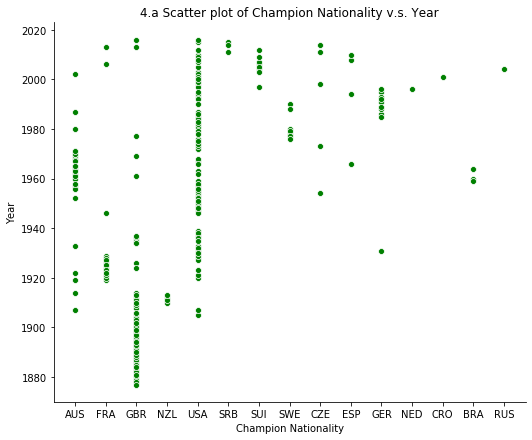

```python
fig_4a=sns.relplot(x='Champion Nationality', y='Year', height=6, aspect=1.25, color='green',data=champ)
fig_4a.set(title='4.a Scatter plot of Champion Nationality v.s. Year')
fig_4a
```

b. Create a grid with four cells. In the first row, show two charts: a histogram showing the number of men’s champions for different countries and a histogram showing the number of women’s champions for different countries. In the second row, show two charts: a histogram showing the number of men’s runners-up for different countries and a histogram showing the number of women’s runners-up for different countries.

```python
champ['Runner-up Nationality']=champ['Runner-up Nationality'].fillna(champ["Runner-up Nationality (Men's)"])
champ['Runner-up']=champ['Runner-up'].fillna(champ['Runner-up'])

champ1=pd.DataFrame({"Gender":champ["Gender"],"Nationality":champ["Champion Nationality"],"Category":"Champion"})
champ2=pd.DataFrame({"Gender":champ["Gender"],"Nationality":champ["Runner-up Nationality"],"Category":"Runner-up"})
champ_b=pd.concat([champ1,champ2])
champ_b.head()
```

|  | Gender | Nationality | Category |
| --- | --- | --- | --- |
| 0 | Men's | AUS | Champion |
| 1 | Men's | AUS | Champion |
| 2 | Men's | AUS | Champion |
| 3 | Men's | AUS | Champion |
| 4 | Men's | FRA | Champion |

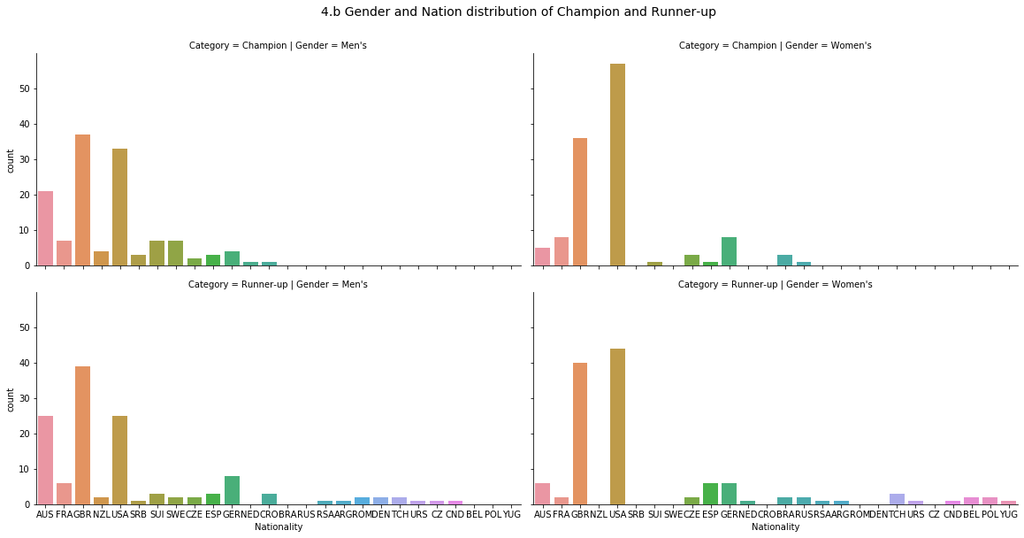

```python
f=sns.catplot(x='Nationality',row='Category', col='Gender',kind='count', height=4, aspect=2, data=champ_b)
fig_4b=f.fig
fig_4b.suptitle("4.b Gender and Nation distribution of Champion and Runner-up", y=1.05, fontsize=14)
```